# Sprint 2 - Predicting Loan Grades

## 🚨 This is the continuation of the previous notebook. If this is the first file you are opening during correctiong, considering reviewing the readme file to understand how this project is structured.

In the previous files:

- ✅ we have looked at our dataset: we have cleaned it and we have split our data into datasets for each of the sprints and tasks
- ✅ we have created a model that can predict loan elegibility

In this file:

- we will create a model that can predict loan grade.

This notebook begins with the same boilerplate as the other ones (imports, basic feature toggles, etc...)

## Imports and initial setup

```python
import ipywidgets as widgets
from IPython.display import display, Markdown, Image, clear_output, HTML
import matplotlib.pyplot as plt
from matplotlib.patches import Rectangle


import numpy as np
import pandas as pd
import seaborn as sns
from scipy import stats
from scipy.stats import chi2_contingency
import missingno as msno
import pygwalker as pyg
import pygwalker_utils.config as pyg_conf

import statsmodels.api as sm

from random import random, seed
import sqlite3 as lite
import logging
import warnings
import ydata_profiling
import iplantuml
import xml.dom.minidom

from sklearn.feature_selection import SelectKBest, f_regression
from sklearn.metrics import (
    ConfusionMatrixDisplay,
    accuracy_score,
    recall_score,
    precision_score,
)
from sklearn.preprocessing import MinMaxScaler, StandardScaler, FunctionTransformer
from sklearn.impute import SimpleImputer
from sklearn.decomposition import PCA
from sklearn.linear_model import LinearRegression, LogisticRegression
from sklearn.model_selection import GridSearchCV
from sklearn.tree import plot_tree
from sklearn.metrics import (
    make_scorer,
    confusion_matrix,
    f1_score,
    PrecisionRecallDisplay,
)
from sklearn.pipeline import Pipeline
from sklearn.impute import KNNImputer
from sklearn.pipeline import make_pipeline
from sklearn.compose import ColumnTransformer
from sklearn.base import BaseEstimator, TransformerMixin
from sklearn.base import clone as clone_pipeline
from sklearn.metrics import classification_report

from sklearn.ensemble import RandomForestClassifier, ExtraTreesClassifier
from sklearn.linear_model import LogisticRegression
from xgboost import XGBClassifier
from sklearn.model_selection import GridSearchCV
from sklearn.svm import SVC
import shap
import yellowbrick

from imblearn.under_sampling import RandomUnderSampler
import joblib

import dask.dataframe as dd
from dask_ml.model_selection import train_test_split as dask_train_test_split

import os
from os import path

from utils import *
from utils import __

from autofeat import AutoFeatRegressor as AFR
from sklearn.model_selection import train_test_split as sklearn_train_test_split
from sklearn.exceptions import DataConversionWarning

import category_encoders as ce

seed(100)
pd.options.display.max_rows = 100
pd.options.display.max_colwidth = 50
util.check("done")
```

```
INFO: Running in offline mode. There might be newer releases available. Please check at https://github.com/Kanaries/pygwalker or https://pypi.org/project/pygwalker.
INFO: Pandas backend loaded 1.5.3
INFO: Numpy backend loaded 1.23.5
INFO: Pyspark backend NOT loaded
INFO: Python backend loaded
```

```
loading utils modules... ✅ completed
configuring autoreload... ✅ completed
✅
```

```python
%reload_ext loans_clean
%reload_ext loans_utils
import loans_clean
from loans_utils import *
```

```python
from imblearn.under_sampling import RandomUnderSampler
```

Let's use `black` to auto-format all our cells so they adhere to PEP8

```python
import lab_black

%reload_ext lab_black
util.patch_nb_black()
# fmt: off
# fmt: on
```

```python
from sklearn import set_config

set_config(transform_output="pandas")
```

```python
logger = util.configure_logging(jupyterlab_level=logging.WARN, file_level=logging.DEBUG)

warnings.filterwarnings("ignore", category=FutureWarning)

# import warnings
# warnings.filterwarnings('error', category=pd.errors.DtypeWarning)
```

```python
def ding(title="Ding!", message="Task completed"):
    """
    this method only works on linux
    """
    for i in range(2):
        !notify-send '{title}' '{message}'
```

## Feature Toggles

Let's also create a simple feature toggle that we can use to skip expensive operations during notebook work (to save myself some time!)

Set it to true if you want to run absolutely everything. Set to false to skip optional steps/exploratory work.

```python
def run_entire_notebook():
    run_all = False
    if not run_all:
        print("skipping optional operation")
    return run_all
```

```python
def perform_split_once_off():
    split_files = False
    if not split_files:
        print("skipping once-off splitting operation")
    return split_files
```

# Machine Learning

## Predicting Loan Grade

For our next iteration, we want to predict loan grade.

For this iteration, we will not use the generated column we crafted (that was only needed for the first iteration).

Since the data cleaning and splitting are all done, this portion of the project (all the rest of them) will only require loading the right slice of data from disk!

This will be a lot more boring, so we will try to keep it light and focus on model performance instead of getting into detailed explanations. It's the same things we have done, with a bit more complexity (multiclass instead of binary classification)

```python
X_hyper = dataset_load(Sprint.grade, Phase.hyperparam, Dataset.X)
y_hyper = dataset_load(Sprint.grade, Phase.hyperparam, Dataset.y)
X_train = dataset_load(Sprint.grade, Phase.train, Dataset.X)
y_train = dataset_load(Sprint.grade, Phase.train, Dataset.y)
```

```python
y_hyper.value_counts()
```

```
C    45397
B    45131
A    28840
D    22721
E     9673
F     3068
G      897
Name: grade, dtype: int64
```

```
Loading from cache [./cached/charts/grade_distribution_before_clustering.png]
```

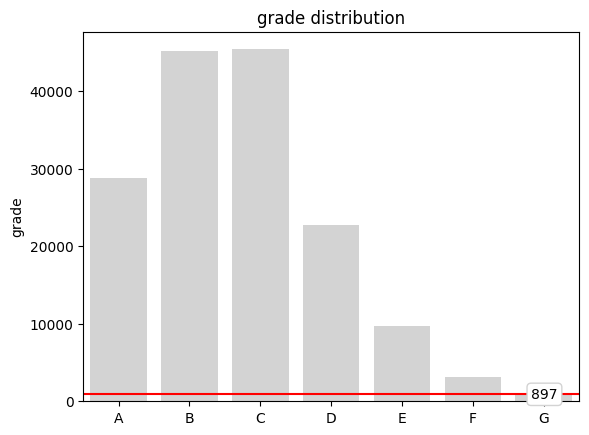

```python
@run
@cached_chart()
def grade_distribution_before_clustering():
    plt.title("grade distribution")
    sns.barplot(
        x=y_hyper.value_counts().index,
        y=y_hyper.value_counts(),
        order=["A", "B", "C", "D", "E", "F", "G"],
        color="lightgrey",
    )

    over_column_g = 0.93
    charts.line(
        y=y_hyper[y_hyper == "G"].count(),
        line_color="red",
        label_format=".0f",
        label_pos=over_column_g,
    )
    return plt.gca()
```

We can see that we are trying to classify a very peculiar label.

- multi-class: 7 distinct values
- unbalanced: each with each own very distinct frequency
- broad range of orders of magnitudes: undersampling to "G" level will not work

For this, we will reshape the data and try to build a simpler classifier:

- A
- B
- C
- D
- X (the rest)

```python
y_hyper[y_hyper == "E"] = "X"
y_hyper[y_hyper == "F"] = "X"
y_hyper[y_hyper == "G"] = "X"

y_train[y_train == "E"] = "X"
y_train[y_train == "F"] = "X"
y_train[y_train == "G"] = "X"
```

```
Loading from cache [./cached/charts/grade_distribution_after_clustering.png]
```

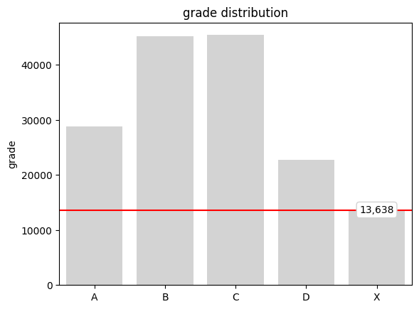

```python
@run
@cached_chart()
def grade_distribution_after_clustering():
    plt.title("grade distribution")
    sns.barplot(
        x=y_hyper.value_counts().index,
        y=y_hyper.value_counts(),
        order=["A", "B", "C", "D", "X"],
        color="lightgrey",
    )

    over_column_e = 0.9
    charts.line(
        y=y_hyper[y_hyper == "X"].count(),
        line_color="red",
        label_format=",.0f",
        label_pos=over_column_e,
    )
    return plt.gca()
```

```python
@cached_with_pickle()
def subsampled_hyper(X_hyper, y_hyper):
    min_sample = y_hyper[y_hyper == "X"].count()

    rus = RandomUnderSampler(
        sampling_strategy={
            "A": min_sample,
            "B": min_sample,
            "C": min_sample,
            "D": min_sample,
            "X": min_sample,
        },
        random_state=42,
    )
    X_hyper, y_hyper = rus.fit_resample(X_hyper, y_hyper)
    return X_hyper, y_hyper


X_hyper, y_hyper = subsampled_hyper(X_hyper, y_hyper)
```

```
Loading from cache [./cached/pickle/subsampled_hyper.pickle]
```

```
Loading from cache [./cached/charts/grade_distribution_after_undersampling.png]
```

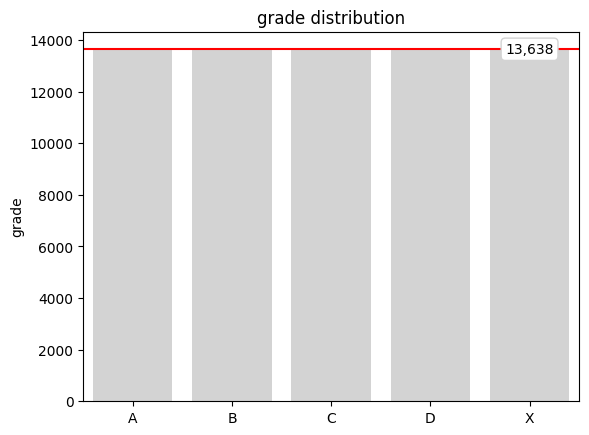

```python
@run
@cached_chart()
def grade_distribution_after_undersampling():
    plt.title("grade distribution")
    sns.barplot(
        x=y_hyper.value_counts().index,
        y=y_hyper.value_counts(),
        order=["A", "B", "C", "D", "X"],
        color="lightgrey",
    )

    charts.line(
        y=y_hyper[y_hyper == "X"].count(),
        line_color="red",
        label_format=",.0f",
        label_pos=0.9,
    )
    return plt.gca()
```

Let's do the same for the training dataset.

```python
y_train
```

```
0          A
1          B
2          B
3          C
4          C
          ..
1756771    A
1756772    A
1756773    D
1756774    B
1756775    B
Name: grade, Length: 1249108, dtype: object
```

```python
@cached_with_pickle()
def subsampled_train(X_train, y_train):
    min_sample = y_train[y_train == "X"].count()
    rus = RandomUnderSampler(
        sampling_strategy={
            "A": min_sample,
            "B": min_sample,
            "C": min_sample,
            "D": min_sample,
            "X": min_sample,
        },
        random_state=42,
    )
    X_train, y_train = rus.fit_resample(X_train, y_train)
    return X_train, y_train


X_train, y_train = subsampled_train(X_train, y_train)
```

```
Loading from cache [./cached/pickle/subsampled_train.pickle]
```

```
Loading from cache [./cached/charts/grade_distribution_after_undersampling_training.png]
```

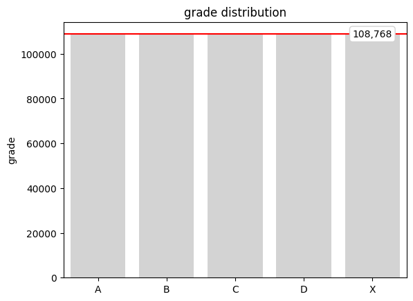

```python
@run
@cached_chart()
def grade_distribution_after_undersampling_training():
    plt.title("grade distribution")
    sns.barplot(
        x=y_train.value_counts().index,
        y=y_train.value_counts(),
        order=["A", "B", "C", "D", "X"],
        color="lightgrey",
    )

    charts.line(
        y=y_train[y_train == "X"].count(),
        line_color="red",
        label_format=",.0f",
        label_pos=0.9,
    )
    return plt.gca()
```

### XGBClassifier (multi-class, single label)

```python
def f1_score_micro(*args, **kwargs):
    score = f1_score(*args, **kwargs, average="micro")
    return score
```

```python
def xgbclassifier_model_optimized():
    X = X_hyper
    y = y_hyper

    # we will set the target to "micro", but realistically, we don't care,
    # as our dataset is perfectly balanced after the undersampling.
    candi = optuna_utils.XgbClassifierCandidateProvider()
    study_name = f"sprint2_xgbclassifier_grade"
    optuna_utils.create_optuna_study(
        study_name=study_name, allow_resume=True, direction="maximize"
    )
    objective = optuna_utils.build_objective_function(
        candi, X, y, scoring_function=f1_score_micro
    )
    optuna_utils.parallelize_optuna(
        study_name, n_processes=1, trials_per_process=1, objective=objective
    )


if run_entire_notebook():
    xgbclassifier_model_optimized()
```

```
skipping optional operation
```

```python
optuna_utils.get_study("sprint2_xgbclassifier_grade").best_value
```

```
0.5042088282739405
```

```python
optuna_utils.get_best_model(
    "sprint2_xgbclassifier_grade", class_name="xgboost.XGBClassifier"
)
```

```
XGBClassifier(colsample_bytree=0.3014258683511573, gamma=0.233447232054033,
              learning_rate=0.05059027679042718, max_depth=5,
              min_child_weight=3, n_estimators=970, n_jobs=16,
              reg_alpha=5.814774705594745e-06, subsample=0.9964087517492259)
```

## Other Models

```python
def sprint2_logreg():
    X = X_hyper
    y = y_hyper
    candi = optuna_utils.LogisticRegressionCandidateProvider()
    study_name = f"sprint2_logreg_grade"
    optuna_utils.create_optuna_study(
        study_name=study_name, allow_resume=True, direction="maximize"
    )
    objective = optuna_utils.build_objective_function(
        candi, X, y, scoring_function=f1_score_micro
    )
    optuna_utils.parallelize_optuna(
        study_name,
        n_processes=15,
        trials_per_process=5,
        objective=objective,
        allow_resume=True,
    )


if run_entire_notebook():
    sprint2_logreg()
```

```
skipping optional operation
```

```python
optuna_utils.get_study("sprint2_logreg_grade").best_value
```

```
0.3625898225546268
```

```python
optuna_utils.get_best_model(
    "sprint2_logreg_grade", class_name="sklearn.linear_model.LogisticRegression"
)
```

```
LogisticRegression(C=158.35914985401206, max_iter=371, n_jobs=16,
                   solver='liblinear')
```

```python
def sprint2_extra_trees():
    X = X_hyper
    y = y_hyper
    candi = optuna_utils.ExtRaTreesCandidateProvider()
    study_name = f"sprint2_extra_trees_grade"
    optuna_utils.create_optuna_study(
        study_name=study_name, allow_resume=True, direction="maximize"
    )
    objective = optuna_utils.build_objective_function(
        candi, X, y, scoring_function=f1_score_micro
    )
    optuna_utils.parallelize_optuna(
        study_name,
        n_processes=12,
        trials_per_process=3,
        objective=objective,
        allow_resume=True,
    )


if run_entire_notebook():
    sprint2_extra_trees()
```

```
skipping optional operation
```

```python
optuna_utils.get_study("sprint2_extra_trees_grade").best_value
```

```
0.4779439800557266
```

```python
optuna_utils.get_best_model(
    "sprint2_extra_trees_grade", class_name="sklearn.ensemble.ExtraTreesClassifier"
)
```

```
ExtraTreesClassifier(max_depth=32, min_samples_leaf=4, min_samples_split=10,
                     n_estimators=700)
```

```python
def sprint2_randforest():
    X = X_hyper
    y = y_hyper
    candi = optuna_utils.RandomForestCandidateProvider()
    study_name = f"sprint2_random_forest_grade"
    optuna_utils.create_optuna_study(
        study_name=study_name, allow_resume=True, direction="maximize"
    )
    objective = optuna_utils.build_objective_function(
        candi, X, y, scoring_function=f1_score_micro
    )
    optuna_utils.parallelize_optuna(
        study_name,
        n_processes=12,
        trials_per_process=3,
        objective=objective,
        allow_resume=True,
    )


if run_entire_notebook():
    sprint2_randforest()
```

```
skipping optional operation
```

```python
optuna_utils.get_study("sprint2_random_forest_grade").best_value
```

```
0.48432321454758764
```

```python
optuna_utils.get_best_model(
    "sprint2_random_forest_grade", class_name="sklearn.ensemble.RandomForestClassifier"
)
```

```
RandomForestClassifier(max_depth=29, max_features='auto', min_samples_leaf=3,
                       min_samples_split=4, n_estimators=727)
```

## Decomposition and Scaling

These experiments are left here just for future reference, but most of them were scraped as the performance was MUCH worse after Scaling and decomposition (PCA() -> MinMaxScaler() ).

The entire log of the experiments and their performance can be found in the `/optuna_studies/study_sprint2_xgbclassifier_grade_with_pca.db` (along with many others combinations...). Some were so bad that got overwritten right afterwards. There was no value in even preserving their logs.

May this serve as a simple record for them:

- PCA Only: 0.33
- PCA + MinMax: 0.34
- MinMax + PCA: 0.42
- All of them well below the performance of the untouched data: 0.51

They have not been fully automated (pipelines/providers, etc..) because of the poor performance we got out of the box (too far below the original data to ever reach it/overtake it.)

```python
def xgbclassifier_model_optimized_with_pca():
    X = X_hyper
    y = y_hyper
    minmax_X = MinMaxScaler().fit_transform(X)
    minmax_pca_X = minmax_X  # PCA(n_components=10).fit_transform(minmax_X)
    pca_y = y
    display(minmax_X)
    display(minmax_pca_X)
    display(pca_y)
    # we will set the target to "micro", but realistically, we don't care,
    # as our dataset is perfectly balanced after the undersampling.
    candi = optuna_utils.XgbClassifierCandidateProvider()
    study_name = f"sprint2_xgbclassifier_grade_with_minmax_only"
    optuna_utils.create_optuna_study(
        study_name=study_name, allow_resume=True, direction="maximize"
    )
    objective = optuna_utils.build_objective_function(
        candi, minmax_pca_X, pca_y, scoring_function=f1_score_micro
    )
    optuna_utils.parallelize_optuna(
        study_name, n_processes=15, trials_per_process=3, objective=objective
    )


if run_entire_notebook():
    xgbclassifier_model_optimized_with_pca()
```

```
skipping optional operation
```

```python
optuna_utils.get_study("sprint2_xgbclassifier_grade_with_minmax_only").best_value
```

```
0.5015251503152955
```

```python
optuna_utils.get_best_model("sprint2_xgbclassifier_grade_with_minmax_only")
```

```
XGBClassifier(colsample_bytree=0.4288296762671395, gamma=1.5124671525024568e-06,
              learning_rate=0.04067676182703638, max_depth=4,
              min_child_weight=6, n_estimators=770, n_jobs=16,
              reg_alpha=0.006359559077989944, subsample=0.90932105227568)
```

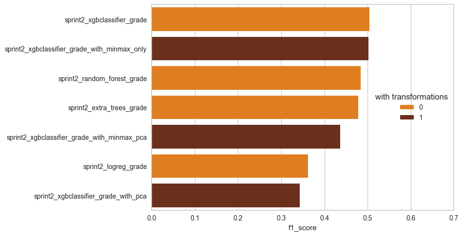

```python
experiments = [
    "sprint2_xgbclassifier_grade",
    "sprint2_logreg_grade",
    "sprint2_extra_trees_grade",
    "sprint2_random_forest_grade",
    "sprint2_xgbclassifier_grade_with_pca",
    "sprint2_xgbclassifier_grade_with_minmax_pca",
    "sprint2_xgbclassifier_grade_with_minmax_only",
]
scores = pd.DataFrame(
    [optuna_utils.get_study(name).best_value for name in experiments],
    index=experiments,
    columns=["f1_score"],
)
scores = scores.sort_values(by="f1_score", ascending=False)
scores["with transformations"] = 0
scores.loc[scores.index.str.contains("_with_"), "with transformations"] = 1
plt.xlim(0, 0.7)
sns.barplot(
    data=scores,
    y=scores.index,
    x="f1_score",
    hue=scores["with transformations"],
    dodge=False,
    palette=["#ff7d00", "#78290f"],
)
```

We can see that, in this specific dataset, performing dimensionality reduction and/or scaling, results in noticeably poorer predictive performance. There is important information captured by the diverging and different scales/magnitudes of the data.

It is also very interesting to see how big the performance improvement is, when we use scaling (after PCA)

The impact of scaling (scaling only) results in negligible performance drop..

## Understanding our performance with `yellowbrick`

Just like before, since we used the hyperparameter split for tuning our model, we will see how well the model generalizes on unseen data. The "train" data split has never been seen by this tuned model, so it will serve us well, for now.

We expect to see similar performance as we saw during HP-tuning, indicating good generalizing behaviour (no specific overfitting to the hyperparamters decided during HP-tuning)

```python
X_train_m, X_test_m, y_train_m, y_test_m = X_hyper, X_train, y_hyper, y_train


@cached_with_pickle()
def sprint2_xgb_classifier_fitted():
    model = optuna_utils.get_best_model("sprint2_xgbclassifier_grade_with_minmax_only")
    return model.fit(X_train_m, y_train_m)


sprint2_xgbclassifier = sprint2_xgb_classifier_fitted()
```

```
Loading from cache [./cached/pickle/sprint2_xgb_classifier_fitted.pickle]
```

### Confusion matrix

```
Loading from cache [./cached/charts/sprint2_xgb_classifier_confusion_matrix.png]
```

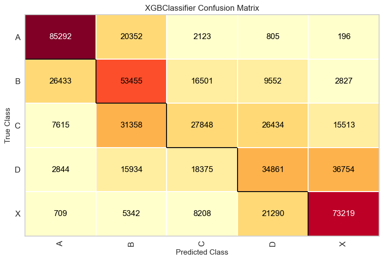

```python
@run
@cached_chart()
def sprint2_xgb_classifier_confusion_matrix():
    cm = yellowbrick.classifier.ConfusionMatrix(sprint2_xgbclassifier, is_fitted=True)
    cm.fit(X_train_m, y_train_m)
    cm.score(X_test_m, y_test_m)
    return cm.show()
```

It's pretty clear that the extremes of the range are performing really well, while the center values (B, C, D) are a bit fuzzy.

Overall 3 of the classes are performing well and the majority of hits fall on them. The distribution is also spreading normally (the further away, the smaller the numbers).

### ClassificationReport

```python
y_train_m.value_counts()
```

```
A    13638
B    13638
C    13638
D    13638
X    13638
Name: grade, dtype: int64
```

```
Loading from cache [./cached/charts/sprint2_xgb_classifier_classification_report.png]
```

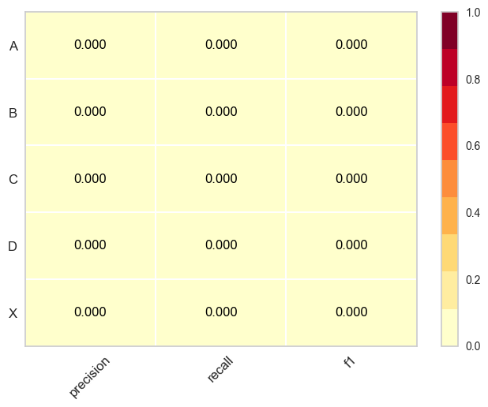

```python
@run
@cached_chart()
def sprint2_xgb_classifier_classification_report():
    cr = yellowbrick.classifier.ClassificationReport(
        sprint2_xgbclassifier, is_fitted=True
    )
    cr.fit(X_train_m, y_train_m)
    cr.score(X_test_m, y_test_m)
    return cr.show()
```

It is unclear why this report appears to fail and show all 0.0 ... when the scikit learn one calculates things correctly.

there are [no obvious github issues open](https://github.com/DistrictDataLabs/yellowbrick/issues?q=is%3Aissue+is%3Aopen+classification+report) for this behaviour, so I suspect it's a rare alignment of planets, more than a bug in the library...

```python
@cached_with_pickle()
def test_classification_report_from_scikitlearn():
    return sprint2_xgbclassifier.predict(X_test_m)


predicted = test_classification_report_from_scikitlearn()
print(classification_report(y_test_m, predicted))
```

```
Loading from cache [./cached/pickle/test_classification_report_from_scikitlearn.pickle]
              precision    recall  f1-score   support

           A       0.69      0.78      0.74    108768
           B       0.42      0.49      0.45    108768
           C       0.38      0.26      0.31    108768
           D       0.38      0.32      0.35    108768
           X       0.57      0.67      0.62    108768

    accuracy                           0.51    543840
   macro avg       0.49      0.51      0.49    543840
weighted avg       0.49      0.51      0.49    543840
```

```
Loading from cache [./cached/charts/sprint2_xgb_classifier_class_prediction_error.png]
```

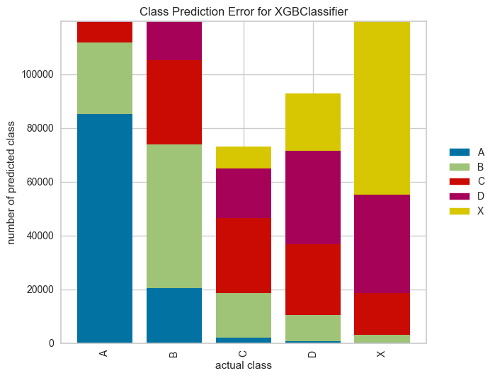

```python
@run
@cached_chart()
def sprint2_xgb_classifier_class_prediction_error():
    cpe = yellowbrick.classifier.ClassPredictionError(
        sprint2_xgbclassifier, is_fitted=True
    )
    cpe.fit(X_train_m, y_train_m)
    cpe.score(X_test_m, y_test_m)
    return cpe.show()
```

This chart shows the same as the previous one, but as stacked bars instead of as a coloured heatmap.

The only new/interesting thing we are seeing here is that class C is very underrepresented.

```
Loading from cache [./cached/charts/sprint2_xgb_classifier_rocauc.png]
```

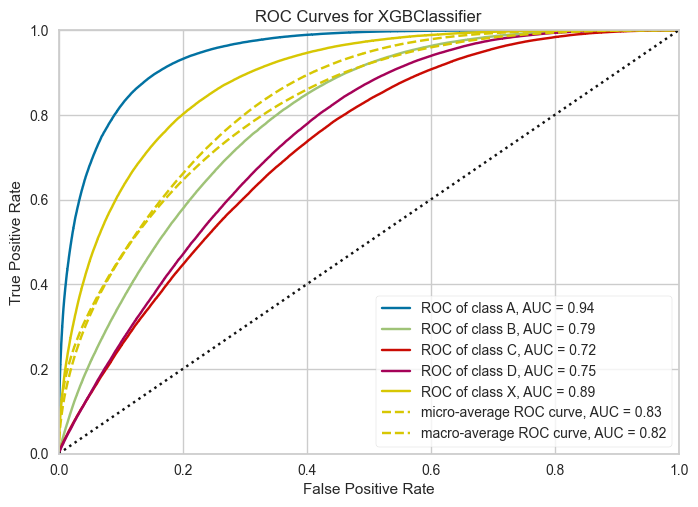

```python
@run
@cached_chart()
def sprint2_xgb_classifier_rocauc():
    rocauc = yellowbrick.classifier.ROCAUC(sprint2_xgbclassifier, is_fitted=True)
    rocauc.fit(X_train_m, y_train_m)
    rocauc.score(X_test_m, y_test_m)
    return rocauc.show()
```

Just a standard ROC AUC curves plot for all of the classes.

It is fascinating to see how strong prediction for class A is. One thing to improve this model would be to analyze and compare class A and class C and see if there are any insights we could dig deeper maybe the dataset needs more data for classes C, to identify them better.

This has not been done due to time constraints.

# A meta analysis of Optuna trials & performance

```
Loading from cache [./cached/charts/optuna_trials_performance.png]
```

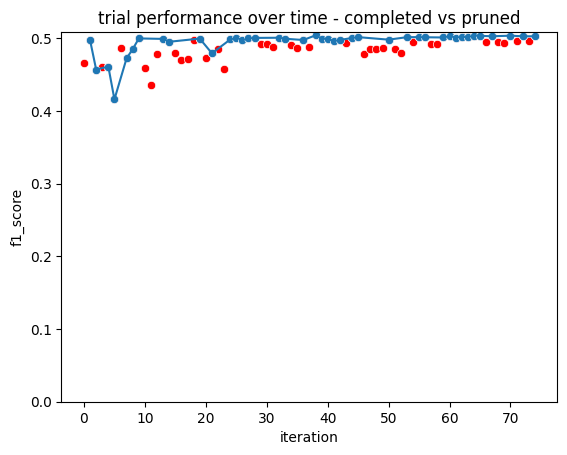

```python
@run
@cached_chart()
def optuna_trials_performance():
    trial_scores_completed = dict(
        map(
            lambda trial: [trial.number, trial.value]
            if trial.state == 1
            else [trial.number, None],
            optuna_utils.get_study("sprint2_xgbclassifier_grade").trials,
        )
    )
    trial_scores_all = dict(
        map(
            lambda trial: [trial.number, trial.value],
            optuna_utils.get_study("sprint2_xgbclassifier_grade").trials,
        )
    )
    sns.lineplot(trial_scores_completed)
    sns.scatterplot(trial_scores_all, color="red")
    sns.scatterplot(trial_scores_completed)
    plt.xlabel("iteration")
    plt.ylabel("f1_score")
    plt.ylim(0)
    plt.title("trial performance over time - completed vs pruned")
    return plt.gca()
```

The time we spent implementing optuna's pruning in my code seems like a worthy investment. Optuna clearly notices when a set of hyperparameters are underperforming and can kill that experiment early.

Nice!

```
Loading from cache [./cached/charts/optuna_trials_performance_zoomin.png]
```

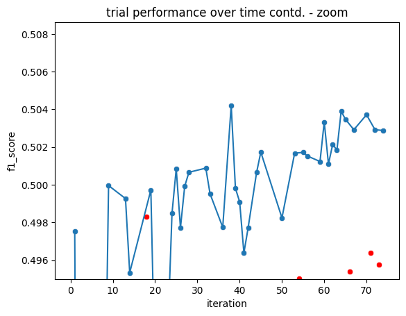

```python
@run
@cached_chart()
def optuna_trials_performance_zoomin():
    trial_scores_completed = dict(
        map(
            lambda trial: [trial.number, trial.value]
            if trial.state == 1
            else [trial.number, None],
            optuna_utils.get_study("sprint2_xgbclassifier_grade").trials,
        )
    )
    trial_scores_all = dict(
        map(
            lambda trial: [trial.number, trial.value],
            optuna_utils.get_study("sprint2_xgbclassifier_grade").trials,
        )
    )
    sns.lineplot(trial_scores_completed)
    sns.scatterplot(trial_scores_all, color="red")
    sns.scatterplot(trial_scores_completed)

    plt.ylim(0.495)
    plt.xlabel("iteration")
    plt.ylabel("f1_score")
    plt.title("trial performance over time contd. - zoom")
    return plt.gca()
```

A meta analysis of Optuna trials shows that most of the trials after the first 30/40 are only useful in refining/finely tuning the performance very marginally (from ~0.501 to ~0.503).. Probably not worth the effort to run hyper parameter tuning for too long (for this specific project!)

## Windows' Poor performance - even with multithreading

I also attempted to run this on my non-laptop computer (which is much newer).

Despite the numerous attempts to see if I could get better performance, the attempt was futile.

| trial | number | study | state | start | end |
| --- | --- | --- | --- | --- | --- |
| 1 | 0 | 1 | FAIL | 2023-09-04 22:05:22.040927 | 2023-09-04 22:26:15.900150 |
| 2 | 1 | 1 | COMPLETE | 2023-09-04 22:05:25.207228 | 2023-09-04 22:22:49.361610 |
| 3 | 2 | 1 | FAIL | 2023-09-04 22:05:28.411309 | 2023-09-04 22:47:48.362501 |
| 4 | 3 | 1 | COMPLETE | 2023-09-04 22:05:31.846729 | 2023-09-04 22:22:40.889677 |
| 5 | 4 | 1 | RUNNING | 2023-09-04 22:05:35.111873 |  |
| 6 | 5 | 1 | COMPLETE | 2023-09-04 22:05:38.349306 | 2023-09-04 22:28:39.443989 |
| 7 | 6 | 1 | COMPLETE | 2023-09-04 22:05:41.653371 | 2023-09-04 22:12:02.339124 |
| 8 | 7 | 1 | FAIL | 2023-09-04 22:05:45.268575 | 2023-09-04 22:23:11.930093 |
| 9 | 8 | 1 | COMPLETE | 2023-09-04 22:05:48.968090 | 2023-09-04 22:07:59.477087 |
| 10 | 9 | 1 | COMPLETE | 2023-09-04 22:05:52.788810 | 2023-09-04 22:16:47.396793 |
| 11 | 10 | 1 | FAIL | 2023-09-04 22:05:56.826596 | 2023-09-04 22:33:03.796348 |
| 12 | 11 | 1 | COMPLETE | 2023-09-04 22:06:01.010069 | 2023-09-04 22:29:37.177183 |
| 13 | 12 | 1 | FAIL | 2023-09-04 22:06:05.488447 | 2023-09-04 22:30:23.826937 |
| 14 | 13 | 1 | COMPLETE | 2023-09-04 22:06:09.884254 | 2023-09-04 22:27:58.911224 |
| 15 | 14 | 1 | FAIL | 2023-09-04 22:06:14.532474 | 2023-09-04 22:22:54.470762 |
| 16 | 15 | 1 | FAIL | 2023-09-04 22:07:59.516222 | 2023-09-04 22:25:22.691553 |
| 17 | 16 | 1 | FAIL | 2023-09-04 22:12:02.378259 | 2023-09-04 22:25:40.130826 |
| 18 | 17 | 1 | FAIL | 2023-09-04 22:16:47.444960 | 2023-09-04 22:57:24.045545 |
| 19 | 18 | 1 | COMPLETE | 2023-09-04 22:22:40.923795 | 2023-09-04 22:52:07.972303 |
| 20 | 19 | 1 | FAIL | 2023-09-04 22:22:49.403757 | 2023-09-04 22:39:06.383221 |
| 21 | 20 | 1 | FAIL | 2023-09-04 22:22:54.503877 | 2023-09-04 22:26:22.973373 |
| 22 | 21 | 1 | FAIL | 2023-09-04 22:23:11.959194 | 2023-09-04 22:41:56.215612 |
| 23 | 22 | 1 | COMPLETE | 2023-09-04 22:25:22.713630 | 2023-09-04 23:01:41.925060 |
| 24 | 23 | 1 | FAIL | 2023-09-04 22:25:40.161934 | 2023-09-04 22:33:31.924085 |

Lessons learned:

- Windows-specific bugs: Spinning up subprocesses that spawn from Jupyter-managed Kernel is not supported and is a [well known problem - see StackOverflow](https://stackoverflow.com/questions/45719956/python-multiprocessing-in-jupyter-on-windows-attributeerror-cant-get-attribut)
  - Switching to using `multiprocess` instead of `multiprocessing` does allow us to spin subprocesses, but the way data, functions and data structures are serialized is cumbersome and makes our code harder to manage.
- Logging and Exception Handling are no handled gracefully either and require manual workarounds (to even begin to detect what is causing the subprocesses to crash).
- The apparent performance gain is negligible when we consider that most of the experiments "finish" early because they *crash* early... so not much gain in that sense...

Compare the performance to how well it works on Linux 🐧 - slightly slower, but no crashes!

| trial | number | study | state | start | end |  |
| --- | --- | --- | --- | --- | --- | --- |
| 17 | 16 | 1 | PRUNED | 2023-09-05 13:21:06.007046 | 2023-09-05 13:52:18.100296 |  |
| 18 | 17 | 1 | PRUNED | 2023-09-05 13:26:03.163226 | 2023-09-05 13:48:24.189345 |  |
| 19 | 18 | 1 | PRUNED | 2023-09-05 13:26:59.728584 | 2023-09-05 14:55:03.665938 |  |
| 20 | 19 | 1 | COMPLETE | 2023-09-05 13:27:16.821904 | 2023-09-05 14:49:56.113971 |  |
| 21 | 20 | 1 | PRUNED | 2023-09-05 13:29:24.812662 | 2023-09-05 13:53:16.950530 |  |
| 22 | 21 | 1 | COMPLETE | 2023-09-05 13:33:54.359492 | 2023-09-05 13:47:12.422884 |  |
| 23 | 22 | 1 | PRUNED | 2023-09-05 13:35:41.614350 | 2023-09-05 14:02:23.820525 |  |
| 24 | 23 | 1 | PRUNED | 2023-09-05 13:36:23.252179 | 2023-09-05 13:46:11.148515 |  |
| 25 | 24 | 1 | COMPLETE | 2023-09-05 13:36:23.995531 | 2023-09-05 14:33:58.693827 |  |
| 26 | 25 | 1 | COMPLETE | 2023-09-05 13:45:48.681604 | 2023-09-05 13:56:15.093534 |  |
| 27 | 26 | 1 | COMPLETE | 2023-09-05 13:46:11.204235 | 2023-09-05 14:01:45.938194 |  |
| 28 | 27 | 1 | COMPLETE | 2023-09-05 13:47:12.492144 | 2023-09-05 14:01:34.186091 |  |
| 29 | 28 | 1 | COMPLETE | 2023-09-05 13:48:24.240003 | 2023-09-05 13:59:26.434074 |  |
| 30 | 29 | 1 | PRUNED | 2023-09-05 13:49:00.628948 | 2023-09-05 14:06:09.301718 |  |
| 31 | 30 | 1 | PRUNED | 2023-09-05 13:52:18.164992 | 2023-09-05 14:26:31.968028 |  |
| 32 | 31 | 1 | PRUNED | 2023-09-05 13:53:17.011024 | 2023-09-05 14:05:31.773261 |  |
| 33 | 32 | 1 | COMPLETE | 2023-09-05 13:56:15.166075 | 2023-09-05 14:48:10.641944 |  |
| 34 | 33 | 1 | COMPLETE | 2023-09-05 13:59:26.496107 | 2023-09-05 14:48:00.129206 |  |
| 35 | 34 | 1 | PRUNED | 2023-09-05 14:01:34.243663 | 2023-09-05 14:14:48.922480 |  |
| 36 | 35 | 1 | PRUNED | 2023-09-05 14:01:46.012462 | 2023-09-05 14:02:21.132534 |  |
| 37 | 36 | 1 | COMPLETE | 2023-09-05 14:02:21.196263 | 2023-09-05 14:11:54.815948 |  |
| 38 | 37 | 1 | PRUNED | 2023-09-05 14:02:23.892003 | 2023-09-05 14:03:53.851387 |  |
| 39 | 38 | 1 | COMPLETE | 2023-09-05 14:03:34.867613 | 2023-09-05 14:37:37.793783 |  |
| 40 | 39 | 1 | COMPLETE | 2023-09-05 14:03:53.911209 | 2023-09-05 14:25:28.701453 |  |

## The developer experience

The developer experience (in Windows) was also terrible (this is why I decided to stick with my slow linux laptop and not switch to the windows desktop)

You can see two branches of exploratory work that did not bring any meaningful results.

[figure not shown]

Needless to say, we will keep working on this slower and underpowered laptop, which gets the work done without hickups 🐌💪

# Next steps

This is the end of sprint 2.

In this sprint, we have have built models to predict the loan grade using algorithms that support multiclass single-label outputs.

We have also seen how some of the recommended ways to improve performance (scaling, dimensionality reduction) didn't quite work, and in fact, dropped the performance of our models up to 30% lower.

We are ready to jump into the next step: making a model to predict the loan's subgrade.

Jump into the notebook for sprint3, whenever you are ready.